# Master notebook for metaRL project

The settings for the script are below, note that ntrials is reset if the task is loaded in. Save after running to create a new notebook each time.

```r
#clears environment
rm(list=ls())
#testing is TRUE means runs with less of everything for speed
testing=TRUE
# settings for script run
newtask=0 #set to 1 to create a new task
taskname='task1' #either creates a task with this name, or loads in one with this name
ntrials=100 #trials in task
probability=0.75 #probability of each shape being rewarded/punished
newchoices=1 #set to 1 to generate new participant choices
participant_multiplier=10 #set to 10 to have ten times the participants in the original study, etc
if (testing==TRUE) participant_multiplier=1
# directories
workingdir='N:/Alex/metaRL'
scriptdir='N:/Alex/metaRL/scripts'
datadir='N:/Alex/metaRL/simulated_data'
taskdir='N:/Alex/metaRL/task/'
# stan parameters
#stanname='metaRL_2a1b.stan'
chain_iter=2e4 # number of iterations for each chain inc. warmup (half)
if (testing==TRUE) chain_iter=2e3
chain_n=4 #4 chains
if (testing==TRUE) chain_n=1
```

This loads the libraries and source files needed to run this script, and sets up RStan

```r
# libraries and source files
library('MASS')
library('boot')
library('matlab')
library('dplyr')
library('reshape')
library('tidyr')
library('rstan')
library('loo')
#options for RSTAN
options(mc.cores = parallel::detectCores())
rstan_options(auto_write = TRUE)
Sys.setenv(LOCAL_CPPFLAGS = '-march=native')
Sys.getenv('LOCAL_CPPFLAGS') #should say '-march=native'
```

```
[1] "-march=native"
```

```r
#functions
source('N:/Alex/metaRL/scripts/simulate_RL.R') #creates a normal distribution around params
source('N:/Alex/metaRL/scripts/simulate_choices.R') #simulates participant choices using Q learning and softmax
source('N:/Alex/metaRL/scripts/create_task.R') #creates task if necessary
source('N:/Alex/metaRL/scripts/estimate_params.R') #recovers parameters
source('N:/Alex/metaRL/scripts/create_sim_matrix.R')#creates the matrix of simulation outputs
```

```r
# creates new task, or loads previously saved one
ifelse(newtask==1, task<- create_task (ntrials, nreversals = 2, probability = probability), load(file.path(taskdir,taskname)))
```

```
[1] "task"
```

```r
if(newtask==0) {ntrials <- nrow(task)} #if loads in a task, sets ntrials to be the number of trials in that task
save(task,file=file.path(taskdir,taskname))
```

Now, we simulate parameters from the Chase et al. 2009 paper.  
Glossary:  
aG = positive learning rate  
aL = negative learning rate  
tr = training phase  
te = test phase  
(not using test phase as this is PIT) pat = patient  
con = control

```
[1] "Diagnostics..."
[1] "mean correct"
[1] "sd correct"
```

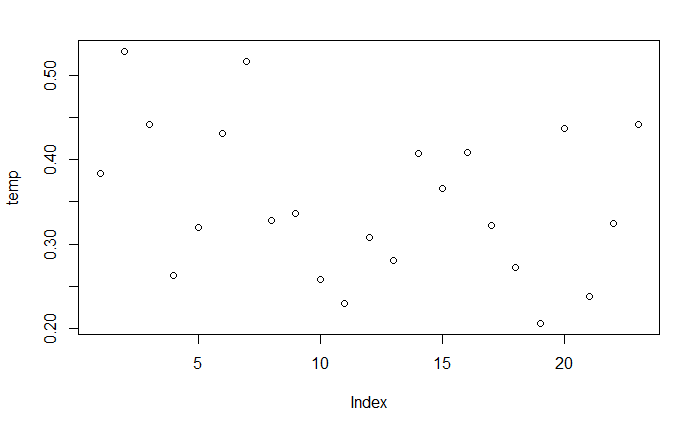

```r
# this part of the script simulates data from the Chase et al. 2009 paper
npat_Chase=23*participant_multiplier #number of participants in Chase paper * multiplier (defined at top)
ncon_Chase=23*participant_multiplier #ditto
nsub_Chase=npat_Chase+ncon_Chase #total subs
#probably going to ignore the test phase as not learning but PIT
#positive learning rate for patients in training phase
Chase_awin_pat <- simulate_RL (n = npat_Chase, est_m = 0.35, est_sd = 0.09)
```

```
[1] "Diagnostics..."
[1] "mean correct"
[1] "sd correct"
```

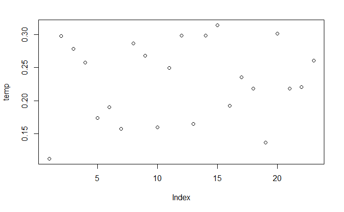

```r
#positive learning rate for controls in training phase
Chase_awin_con <- simulate_RL (n = ncon_Chase, est_m = 0.23, est_sd = 0.06)
```

```
[1] "Diagnostics..."
[1] "mean correct"
[1] "sd correct"
```

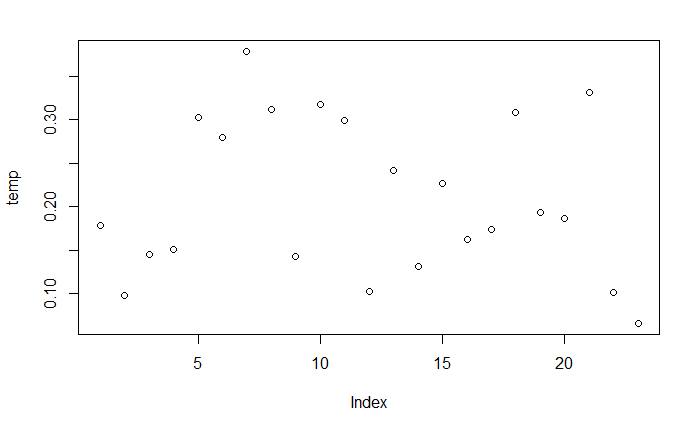

```r
#negative learning rate for patients in training phase
Chase_aloss_pat <- simulate_RL (n = npat_Chase, est_m = 0.21, est_sd = 0.09)
```

```
[1] "Diagnostics..."
[1] "mean correct"
[1] "sd correct"
```

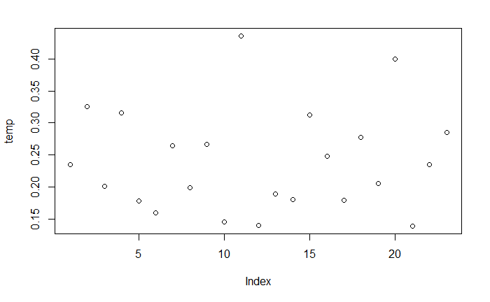

```r
#negative learning rate for controls in training phase
Chase_aloss_con <- simulate_RL (n = ncon_Chase, est_m = 0.24, est_sd = 0.08)
```

```
[1] "Diagnostics..."
[1] "mean correct"
[1] "sd correct"
```

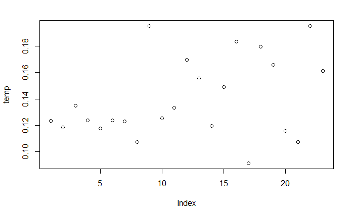

```r
#exploration/exploitation (essentially beta) for patients in training phase
Chase_beta_pat <- simulate_RL (n = npat_Chase, est_m = 0.14, est_sd = 0.03)
```

```
[1] "Diagnostics..."
[1] "mean correct"
[1] "sd correct"
```

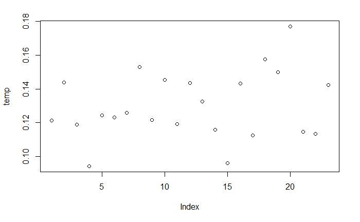

```r
#exploration/exploitation (essentially beta) for controls in training phase
Chase_beta_con <- simulate_RL (n = ncon_Chase, est_m = 0.13, est_sd = 0.02)
```

And generate data from the Kumar 2018 paper.

```
[1] "Diagnostics..."
[1] "mean correct"
[1] "sd correct"
```

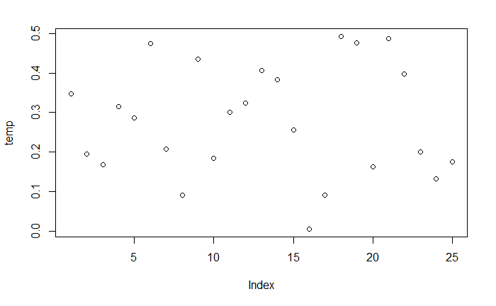

```r
npat_Kumar=25*participant_multiplier #number of participants in Kumar paper * multiplier (defined at top)
ncon_Kumar=26*participant_multiplier #ditto
nsub_Kumar=npat_Kumar+ncon_Kumar #total subs for paper
#positive learning rate for patients
Kumar_awin_pat <- simulate_RL (n = npat_Kumar, est_m = 0.28, est_sd = 0.14)
```

```
[1] "Diagnostics..."
[1] "mean correct"
[1] "sd correct"
```

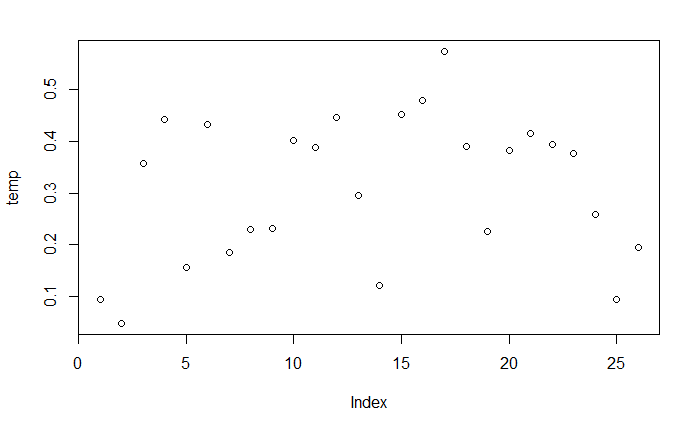

```r
#positive learning rate for controls
Kumar_awin_con <- simulate_RL (n = ncon_Kumar, est_m = 0.31, est_sd = 0.14)
```

```
[1] "Diagnostics..."
```

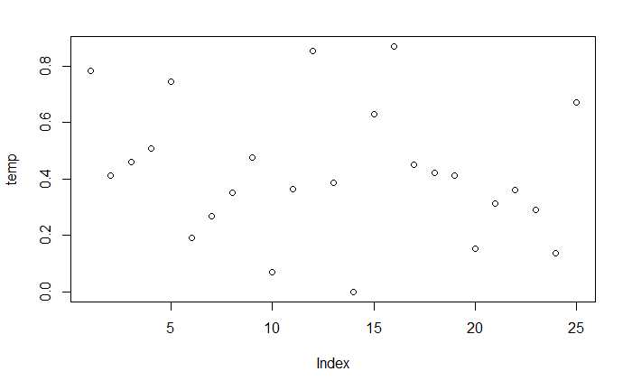

```r
#negative learning rate for patients
Kumar_aloss_pat <- simulate_RL (n = npat_Kumar, est_m = 0.42, est_sd = 0.24)
```

```
[1] "Diagnostics..."
[1] "mean correct"
[1] "sd correct"
```

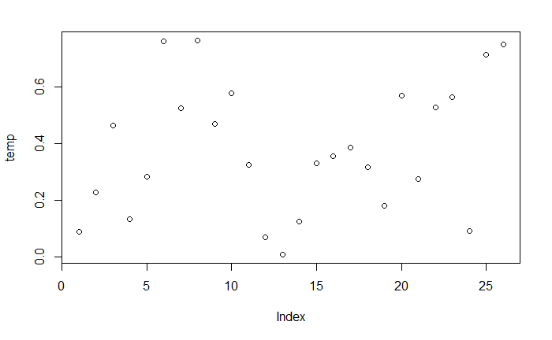

```r
#negative learning rate for controls
Kumar_aloss_con <- simulate_RL (n = ncon_Kumar, est_m = 0.38, est_sd = 0.23)
```

```
[1] "Diagnostics..."
```

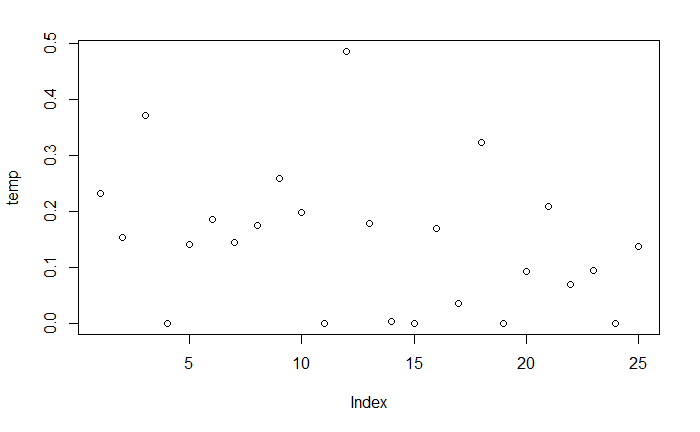

```r
#positive beta for patients
Kumar_betawin_pat <- simulate_RL (n = npat_Kumar, est_m = 0.13, est_sd = 0.15)
```

```
[1] "Diagnostics..."
```

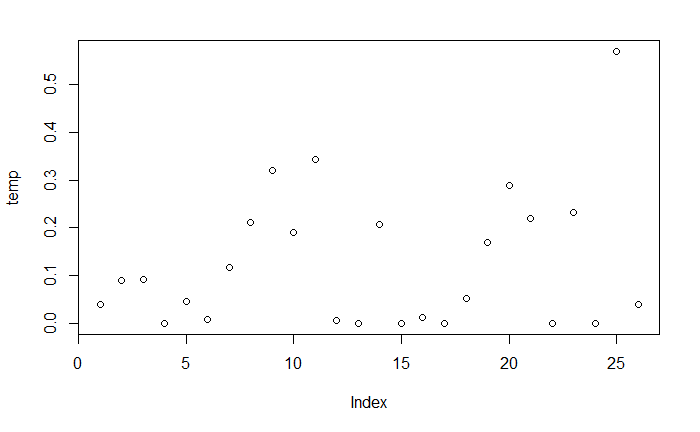

```r
#positive beta for controls
Kumar_betawin_con <- simulate_RL (n = ncon_Kumar, est_m = 0.11, est_sd = 0.16)
```

```
[1] "Diagnostics..."
```

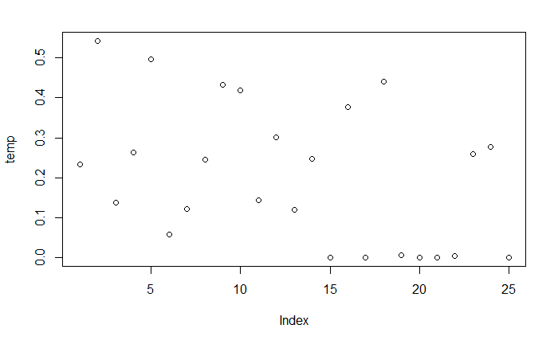

```r
#negative beta for patients
Kumar_betaloss_pat <- simulate_RL (n = npat_Kumar, est_m = 0.19, est_sd = 0.20)
```

```
[1] "Diagnostics..."
```

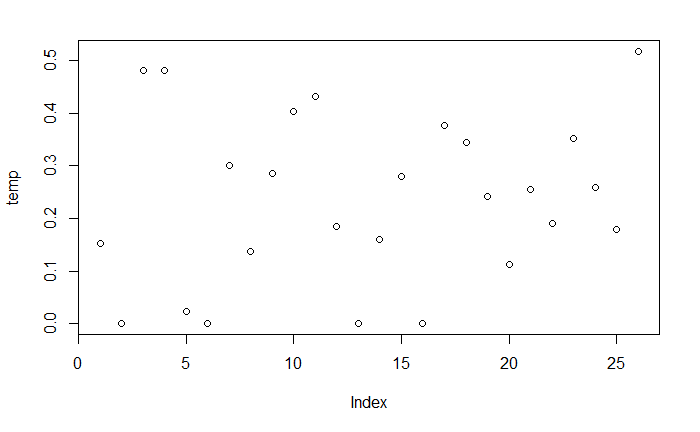

```r
#negative beta for controls
Kumar_betaloss_con <- simulate_RL (n = ncon_Kumar, est_m = 0.23, est_sd = 0.17)
```

The below simulates patient choices using the simulated params from Chase et al. 2009

```r
#simulate 'participant' choices
if (newchoices==1){
  temp1<- matrix(data=NA, nrow <- ntrials*(nsub_Chase), ncol<- 7)
  temp2<- matrix(data=NA, nrow <- ntrials*(nsub_Kumar), ncol<- 7)
  #patients Chase paper
  for (pat in 1:npat_Chase){
    choices<- simulate_choices (Chase_awin_pat[pat], Chase_aloss_pat[pat], Chase_beta_pat[pat],'empty', task) #null:no separate           betaloss
    temp1<-create_sim_matrix(temp1,1,1,pat,task,choices,ntrials)
    rm(choices)
  }
  #controls Chase paper
  for (con in 1:ncon_Chase){
    choices<- simulate_choices (Chase_awin_con[con], Chase_aloss_con[con], Chase_beta_con[con],'empty', task)
    temp1<-create_sim_matrix(temp1,1,0,npat_Chase+con,task,choices,ntrials)
    rm(choices)
  }
  #patients Kumar paper
    for (pat in 1:npat_Kumar){
    choices<- simulate_choices (Kumar_awin_pat[pat], Kumar_aloss_pat[pat], Kumar_betawin_pat[pat],
                                Kumar_betaloss_pat[pat],task)
    temp2<-create_sim_matrix(temp2,2,1,pat,task,choices,ntrials)
    rm(choices)
  }
  #controls Kumar paper
  for (con in 1:ncon_Kumar){
    choices<- simulate_choices (Kumar_awin_con[con], Kumar_aloss_con[con], Kumar_betawin_con[con],
                                Kumar_betaloss_con[con],task)
    temp2<-create_sim_matrix(temp2,2,0,npat_Kumar+con,task,choices,ntrials)
    rm(choices)
  }
  simulated_data<-rbind(temp1,temp2)
  rm(temp1,temp2)
} else {
  load('N:/Alex/metaRL/simulated_data/simulated_data')
}
```

Now, we save the simulated data.

```r
save(simulated_data,file='N:/Alex/metaRL/simulated_data/simulated_data')
```

We want to see if the parameters are recoverable. Therefore, we need to go from these choices back to the parameters that generated them (this does this for the Chase paper).

```r
stanname='metaRL_Chase2.stan'
stanfile <- file.path(scriptdir, stanname)
simulated_data<-as.data.frame(simulated_data)
colnames(simulated_data)<- c('study','pat/con','id','trial','reward','pun','choices')
rm(rewardA,punA,choices)
```

```
object 'rewardA' not foundobject 'punA' not foundobject 'choices' not found
```

```r
simulated_data_Chase<-subset(simulated_data,simulated_data$study==1) #Chase data
rewardA <- select(simulated_data_Chase,c('id','trial','reward')) %>% spread(id, reward, fill = 0)
rewardA$trial <- NULL
punishA <- select(simulated_data_Chase,c('id','trial','pun')) %>% spread(id, pun, fill = 0)
punishA$trial <- NULL
choices <- select(simulated_data_Chase,c('id','trial','choices')) %>% spread(id, choices, fill = 0)
choices$trial <- NULL
Chase_data<-list(ntrials=ntrials,nsub=nsub_Chase,includeTrial = rep(1,ntrials),  rewardA=rewardA,punishA=punishA,choices=choices)
Chase_fit <- stan(file = stanfile, data = Chase_data, iter=chain_iter, chains = chain_n) #add working dir?
```

```
There were 173 divergent transitions after warmup. Increasing adapt_delta above 0.8 may help. See
http://mc-stan.org/misc/warnings.html#divergent-transitions-after-warmupThere were 1 chains where the estimated Bayesian Fraction of Missing Information was low. See
http://mc-stan.org/misc/warnings.html#bfmi-lowExamine the pairs() plot to diagnose sampling problems
```

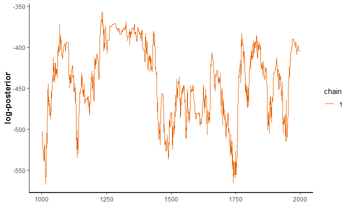

```r
save(Chase_fit, file=file.path(datadir,'Chase_fit'))
traceplot(Chase_fit,'lp__')
```

```r
# draws_Chase<- extract(Chase_fit)
summary_Chase<- summary(Chase_fit)
Chase_loglike<- extract_log_lik(Chase_fit, parameter_name = "loglik", merge_chains = TRUE)
loo(Chase_loglike)
```

[output not shown]

```
Computed from 1000 by 46 log-likelihood matrix
```

|  | Estimate | SE |
| --- | --- | --- |
| elpd_loo | -9920.0 | 166.7 |
| p_loo | 6587.6 | 174.8 |
| looic | 19840.1 | 333.3 |

```
------
Monte Carlo SE of elpd_loo is NA.

Pareto k diagnostic values:
                         Count Pct.    Min. n_eff
(-Inf, 0.5]   (good)      0      0.0%  <NA>
 (0.5, 0.7]   (ok)        0      0.0%  <NA>
   (0.7, 1]   (bad)       0      0.0%  <NA>
   (1, Inf)   (very bad) 46    100.0%  1
See help('pareto-k-diagnostic') for details.
```